# Introduction

In the face of escalating energy prices and the imperative to transition to renewable energy sources, optimising battery usage is emerging as a key strategy to mitigate escalating electricity costs while contributing to sustainable energy practices. Our project addresses this pressing issue by harnessing the power of Reinforcement Learning (RL) to develop an intelligent algorithm capable of dynamically managing battery operations in response to fluctuating energy market dynamics. At its core, our model ingests multiple data streams, including electricity market dynamics, battery health information and consumption patterns. The decision-making process unfolds on a daily basis, with our model strategically assessing which action plan to choose based on forecasts of electricity prices, weather conditions and other pertinent factors.

From a business analytics perspective, our project highlights the intersection of technology, sustainability and corporate social responsibility. By adopting energy optimisation strategies, companies can not only reduce operating costs, but also demonstrate their commitment to environmental stewardship and align with broader societal imperatives and regulatory mandates aimed at combating climate change.

```python
#It can happen that the package import is causing an error. Just executed the cell again and it should work.

import numpy as np
import matplotlib.pyplot as plt
import pandas as pd
import seaborn as sns

from sklearn.cluster import KMeans

from gym import Env
from gym.utils import seeding

import tensorflow as tf
from keras import __version__
tf.keras.__version__ = __version__
import json

from keras.layers import Dense, Flatten
from keras.layers import Dense, Input, Flatten, Dropout
from keras.models import Model
from keras.optimizers import Adam
from rl.agents.dqn import DQNAgent
from rl.policy import EpsGreedyQPolicy, LinearAnnealedPolicy
from rl.memory import SequentialMemory
from keras.src.saving import serialization_lib
serialization_lib.enable_unsafe_deserialization()
from tensorflow.keras.optimizers.legacy import Adam
from rl.callbacks import FileLogger

from rl.agents.dqn import DQNAgent
from rl.policy import EpsGreedyQPolicy
from rl.memory import SequentialMemory
import scipy.stats as stats

#surpress all warnings
import warnings
warnings.filterwarnings("ignore")
```

```
WARNING:tensorflow:From c:\Users\janle\AppData\Local\Programs\Python\Python311\Lib\site-packages\rl\agents\ddpg.py:9: The name tf.disable_eager_execution is deprecated. Please use tf.compat.v1.disable_eager_execution instead.
```

# Demand profile creation

In the absence of a given load profile for these years, a demand profile is created. This profile should describe an industrial customer who has most of his demand during working hours on weekdays and a rather low demand at weekends and at night. For more realistic values, a random value is added to the load profile to challenge the model.

```python
load1 = np.full(24, 1000)
load1[8:17] += 500
load1[12:13] -= 150
load2 = np.full(24, 1000)

date_range = pd.date_range(start='2019-01-01', end='2023-12-31', freq='H')

df = pd.DataFrame(index=date_range)
df['day_of_week'] = df.index.dayofweek
df['hour'] = df.index.hour
df['industrial_demand'] = np.where(df['day_of_week'] < 5, load1[df['hour']], load2[df['hour']])
df['industrial_demand'] = df['industrial_demand'] + df['industrial_demand'] * np.random.rand(len(df['industrial_demand'])) / 20
df.reset_index(inplace=True)
df.rename(columns={'index':'date'}, inplace=True)

#df.to_csv('../Data/industrial_demand.csv', index=False)
```

## Data Cleaning

Each separate input stream of data is merged into a data frame that will be used further in the model. As the model will be dealing with 24-hour action plans, the data is collapsed in the sense that each day has 24 hours and each year has 365 days. This allows for easier handling of the data in the model itself. The data is collected from the ENTSO-E transparency platform, which is the organisation of all transmission system operators in Europe. The quality of the data is very high and reliable. All data is available at noon the day before the actual production day. This ensures that there is no data leakage. In rare cases, some publications may be delayed, but in a real business scenario, the data could be purchased from other private institutions. The model currently runs on data from Germany only, but could be extended to other markets.

```python
load = pd.read_csv('../Data/load.csv')
load['date'] = pd.to_datetime(load['date'], format='%Y-%m-%d %H:%M:%S')
prices = pd.read_csv('../Data/prices.csv')
prices['date'] = pd.to_datetime(prices['date'], format='%Y-%m-%d %H:%M:%S')
res_gen = pd.read_csv('../Data/res_gen.csv')
res_gen['date'] = pd.to_datetime(res_gen['date'], format='%Y-%m-%d %H:%M:%S')
#residual_generation = pd.read_csv('../Data/residual_generation.csv')
industrial_demand = pd.read_csv('../Data/industrial_demand.csv')
industrial_demand['date'] = pd.to_datetime(industrial_demand['date'], format='%Y-%m-%d %H:%M:%S')

#create a Df with a date column with 24 hours for each day from 1.1.2019 until 31.12.2023
date = pd.DataFrame()
date['date'] = pd.date_range(start='2019-01-01', end='2024-01-01', freq='H')
#group by date and count the hours
date['hour'] = date['date'].dt.hour
date['day'] = date['date'].dt.day
date['month'] = date['date'].dt.month
date['year'] = date['date'].dt.year
date['weekday'] = date['date'].dt.weekday

#drop last row
date = date[:-1]

#merge them all on date
data = pd.merge(date, load, on='date', how='left')
data = pd.merge(data, prices, on='date', how='left')
data = pd.merge(data, res_gen, on='date', how='left')
#data = pd.merge(data, residual_generation, on='date')
data = pd.merge(data, industrial_demand, on='date', how='left')

#drop price_FRA
data = data.drop(columns=['price_FRA'])
help_data = pd.DataFrame()
help_data['date'] = pd.to_datetime(data['date'], format='%Y-%m-%d %H:%M:%S')
help_data['industrial_demand'] = data['industrial_demand']

#drop all columns without GER in the name
data = data[data.columns[data.columns.str.contains('GER')]]
data['date'] = help_data['date']
data['industrial_demand'] = help_data['industrial_demand']
data['year'] = data['date'].dt.year
data['month'] = data['date'].dt.month
data['day'] = data['date'].dt.day
data['hour'] = data['date'].dt.hour
data['weekday'] = data['date'].dt.weekday

#replace n/e with np.NaN
data = data.replace('n/e', np.NaN)
data = data.ffill()
# drop 29.02.2020
data = data[~((data['year'] == 2020) & (data['month'] == 2) & (data['day'] == 29))]

print(data.isnull().sum())

data.to_csv('data.csv', index=False)
```

```
load_GER                    0
price_GER                   0
solar_forecastGER           0
windoffshore_forecastGER    0
windonshore_forecastGER     0
date                        0
industrial_demand           0
year                        0
month                       0
day                         0
hour                        0
weekday                     0
dtype: int64
```

# Descriptive analysis

The descriptive analysis should show the correlation or even causality between the input data used and the result of the algorithm. Since the outcome is an action plan of a classification, the model needs to match the price pattern of a single day with an action plan. According to the academic literature, there are typical input features for predicting electricity prices. Before introducing the input characteristics, a brief description of the electricity market is given.

Electricity prices are set using merit order. All generators are ranked according to their bid price. This price is usually the marginal cost. For renewables, these marginal costs are zero. After that, nuclear is often the next cheapest source, followed by coal and then gas. The same method is applied to the demand bids, but in reverse order. The bids with the highest price are satisfied first, until the demand curve intersects the supply curve. This point determines the volume and price at which each kWh is sold in that hour. This is done for each of the 24 hours of the day, one day in advance, after noon. Therefore, bids and offers must be submitted before 12:00 noon the day ahead. In order to estimate the price of electricity, an estimate of the marginal costs of the last generator is required. In markets such as Germany, where the share of renewable energy is very high, it is important to estimate how much capacity needs to be provided by conventional generators in order to meet demand, the so-called residual generation. This amount determines which generator sets the price. The price at which this generator offers depends on its marginal costs, i.e. the cost of fuel. Assuming that the fuel price changes little during the day, it can be assumed that the electricity price depends only on the amount of residual generation. The amount of remaining generation would also describe the price pattern of a single day, ignoring the absolute level of prices.

The goal in this project is just arbitrary charging and discharging behaviour. Therefore the absolute value is irrelevant, only the relative price is important. Therefore, the aim is to have a good prediction of how much residual generation will be needed in each hour. To do this, the predicted load/demand at grid level and the estimated amount of electricity produced by renewable energy sources is a good indicator of relative prices. What each input looks like on its own and how it interacts with prices is shown in the following chapter.

## Load

The forecast load is illustrated in the heat map below and shows the peak demand of around 65 GW at midday on normal weekdays. Demand, at least in Germany, is heavily driven by industrial consumers, who shut down or at least reduce their demand over the weekend. It is also interesting to note the sleeping patterns of the Germans. A typical day ends at 11 pm and does not start until 6 am. At the weekend, the average German spends more time in bed and therefore uses less electricity in the early hours of the morning.

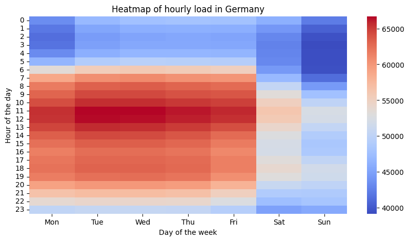

```python
load_pivot = data.pivot_table(index='hour', columns='weekday', values='load_GER', aggfunc='mean')

fig, ax = plt.subplots(figsize=(10, 5))
sns.heatmap(load_pivot, cmap='coolwarm', ax=ax)

ax.set_title('Heatmap of hourly load in Germany')
ax.set_xlabel('Day of the week')
ax.set_ylabel('Hour of the day')
ax.set_xticklabels(['Mon', 'Tue', 'Wed', 'Thu', 'Fri', 'Sat', 'Sun'])
plt.show()
```

Electricity demand not only has a daily and weekly pattern, but also a strong seasonal pattern. In the winter months, electricity consumption is significantly higher than in the summer months, due to the lack of light and higher heating demand. Demand peaks are slightly lower after the energy crisis in the winter of 2021/2022.

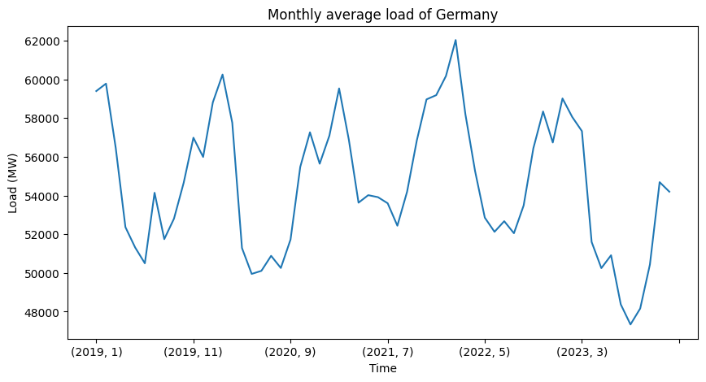

```python
#group data to a yearly and monthly level
yearly_monthly_data = data.groupby(['year', 'month']).mean()

#plot the monthly average load
fig, ax = plt.subplots(figsize=(10, 5))
yearly_monthly_data['load_GER'].plot(ax=ax)
ax.set_title('Monthly average load of Germany')
ax.set_xlabel('Time')
ax.set_ylabel('Load (MW)')
plt.show()
```

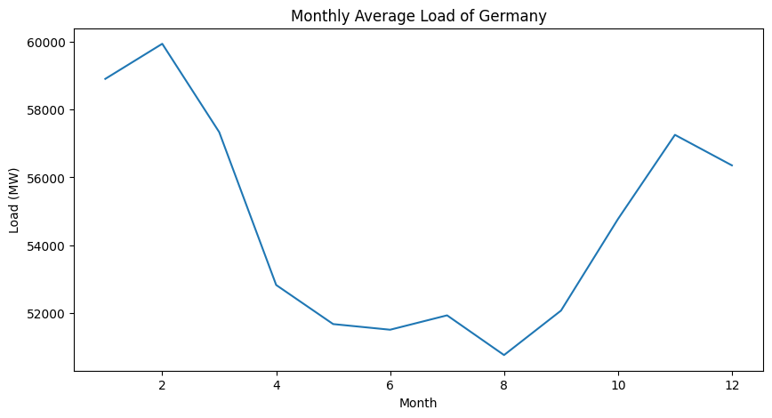

```python
#group data to monthly level
monthly_data = data.groupby(['month']).mean()

#plot the monthly average load
fig, ax = plt.subplots(figsize=(10, 5))
monthly_data['load_GER'].plot(ax=ax)
ax.set_title('Monthly Average Load of Germany')
ax.set_xlabel('Month')
ax.set_ylabel('Load (MW)')
plt.show()
```

## Renewable generation

Renewables have changed electricity markets on the supply side in a big way because of their intermittent production profiles. Before renewables were introduced to the markets, the supply side only knew steady production from conventional generators such as nuclear power plants or gas and coal-fired power plants. This has now changed and there is a clear seasonal and daily pattern. Solar production is high in the summer months and wind production is high in the winter months. On an hourly average, solar production peaks around midday, while wind production is very constant.

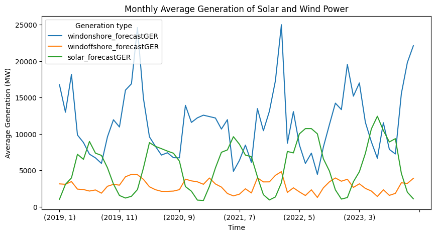

```python
fig, ax = plt.subplots(figsize=(10, 5))
yearly_monthly_data['windonshore_forecastGER'].plot(ax=ax)
yearly_monthly_data['windoffshore_forecastGER'].plot(ax=ax)
yearly_monthly_data['solar_forecastGER'].plot(ax=ax)
ax.set_title('Monthly Average Generation of Solar and Wind Power')
ax.set_xlabel('Time')
ax.set_ylabel('Average Generation (MW)')
plt.legend(title='Generation type')
plt.show()
```

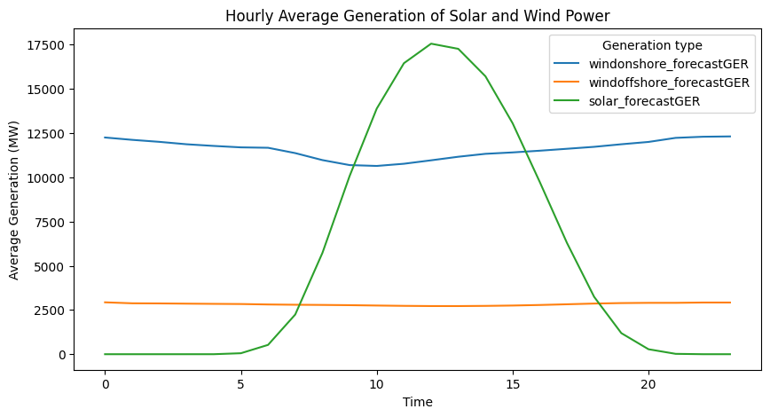

```python
hourly_data = data.groupby(['hour']).mean()

fig, ax = plt.subplots(figsize=(10, 5))
hourly_data['windonshore_forecastGER'].plot(ax=ax)
hourly_data['windoffshore_forecastGER'].plot(ax=ax)
hourly_data['solar_forecastGER'].plot(ax=ax)
ax.set_title('Hourly Average Generation of Solar and Wind Power')
ax.set_xlabel('Time')
ax.set_ylabel('Average Generation (MW)')
plt.legend(title='Generation type')
plt.show()
```

## Prices and correlations

Electricity prices in Germany experienced a rather drastic disruption at the end of 2021 and in 2022. Due to the gas shortage and a general mistrust of the gas and electricity market, prices peaked during these months. By the end of 2023, electricity prices have returned to normal levels and are almost back to pre-crisis prices. Just because the average price was quite high does not mean that there were no hours with very low prices. As there were hours with an extremely high share of renewables, the fluctuation of prices increased in a similar way to the average prices. This is shown in the second graph, which shows the standard deviation of each day averaged on a monthly basis.

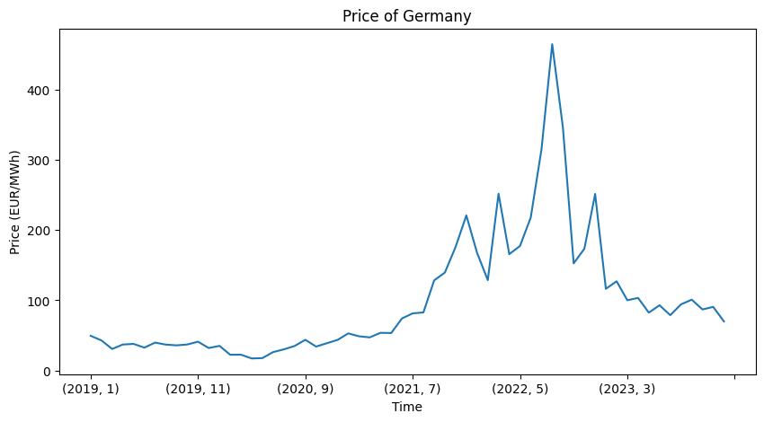

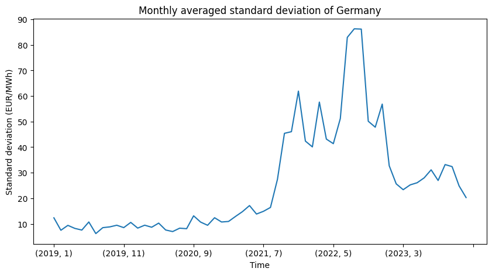

```python
# plot prices
fig, ax = plt.subplots(figsize=(10, 5))
yearly_monthly_data['price_GER'].plot(ax=ax)
ax.set_title('Price of Germany')
ax.set_xlabel('Time')
ax.set_ylabel('Price (EUR/MWh)')
plt.show()

#calculate the standard deviation for each day of the prices in the data df
std_prices = data.groupby(['year','month','day'], as_index=False)['price_GER'].std()
std_prices = std_prices.groupby(['year','month'])['price_GER'].mean()
# plot prices
fig, ax = plt.subplots(figsize=(10, 5))
std_prices.plot(ax=ax)
ax.set_title('Monthly averaged standard deviation of Germany')
ax.set_xlabel('Time')
ax.set_ylabel('Standard deviation (EUR/MWh)')
plt.show()
```

Finally, the correlation between the input characteristics and also with prices is shown. As already mentioned in the short introduction to the electricity markets, there is a negative correlation between the renewable generators and the price, because the amount of remaining generation required is lower. This effect is much stronger for wind generators than for solar generators. This can be explained by the correlation between solar generation and grid load. Solar production is therefore often high at times of high demand, and the two factors partly cancel each other out. Only load has a positive correlation with price.

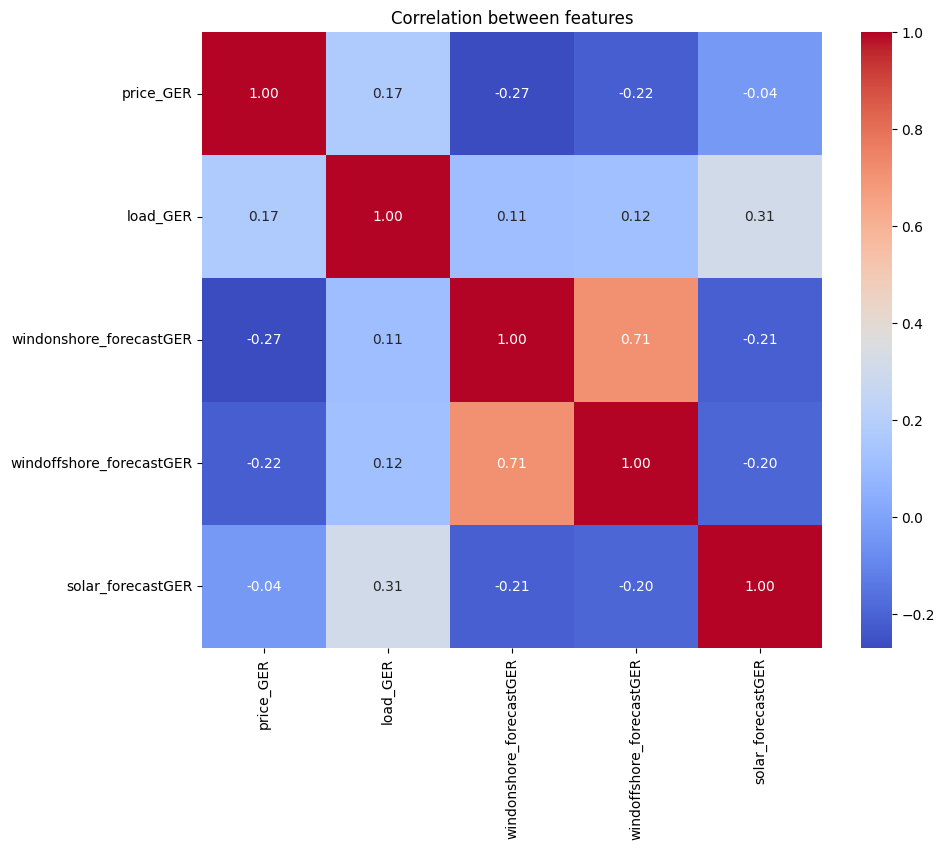

```python
# Correlation Heatmap Between Load and Price
data_corr = data[['price_GER', 'load_GER', 'windonshore_forecastGER', 'windoffshore_forecastGER', 'solar_forecastGER']].corr()
plt.figure(figsize=(10, 8))
sns.heatmap(data_corr, annot=True, cmap='coolwarm', fmt=".2f")

plt.title('Correlation between features')
plt.show()
```

# Action plan generation

The original idea of deciding for each hour whether to charge, discharge or wait was discarded due to the high complexity of 3^24 possible action plans. Instead, the focus is on the best selection from a given set of action plans. The plan is to generate action plans for different price patterns. Therefore, the prices of each day, a vector of 24 elements, are clustered using the k-means algorithm. Before clustering the vector, each day is standardised to have a mean of 0 and a standard deviation of 1. This ensures that only real patterns are detected and not just different levels of electricity prices.

```python
# create a df with one column for each hour and one row for each day
prices_df = data[['price_GER', 'date', 'hour', 'day']].copy()
# drop time from date column
prices_df['date'] = prices_df['date'].dt.date
#prices_df['date'] = pd.to_datetime(prices_df['date'])

prices_tab = prices_df.pivot(index='date',columns='hour', values='price_GER')
prices_tab = prices_tab.dropna()

# Make sure that each rows has a mean of 0 and a standard deviation of 1
prices_tab = prices_tab.apply(lambda x: (x - x.mean()) / x.std(), axis=1)
prices_df = pd.DataFrame(prices_tab, index=prices_tab.index, columns=prices_tab.columns)
```

## Clustering price pattern

The k-means algorithm is run for 3 clusters. The results returned are shown in the figure below. For a clearer visualisation, the centroids are plotted in a second graph. Cluster 0 describes days that have the highest peaks in the morning and evening compared to the other clusters, and a generally high price level throughout the day. Cluster 1 describes mostly sunny summer days. These days are characterised by very low prices at midday and relatively high prices during the night. The last cluster 2 describes typical winter days. Wind generators produce a lot of electricity and prices drop during the night. During the day, the lack of solar generation becomes visible and relatively high prices can be observed.

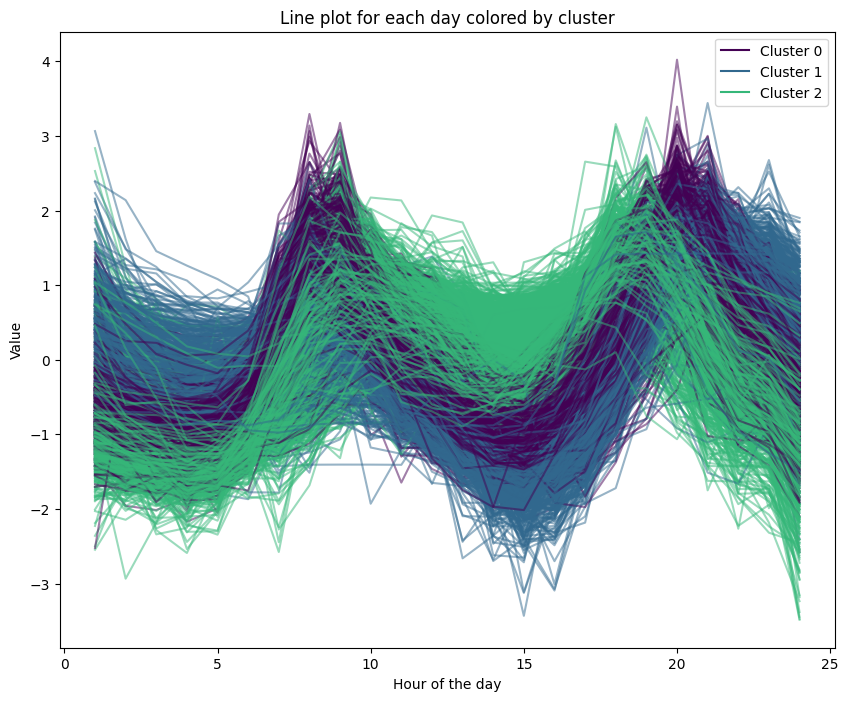

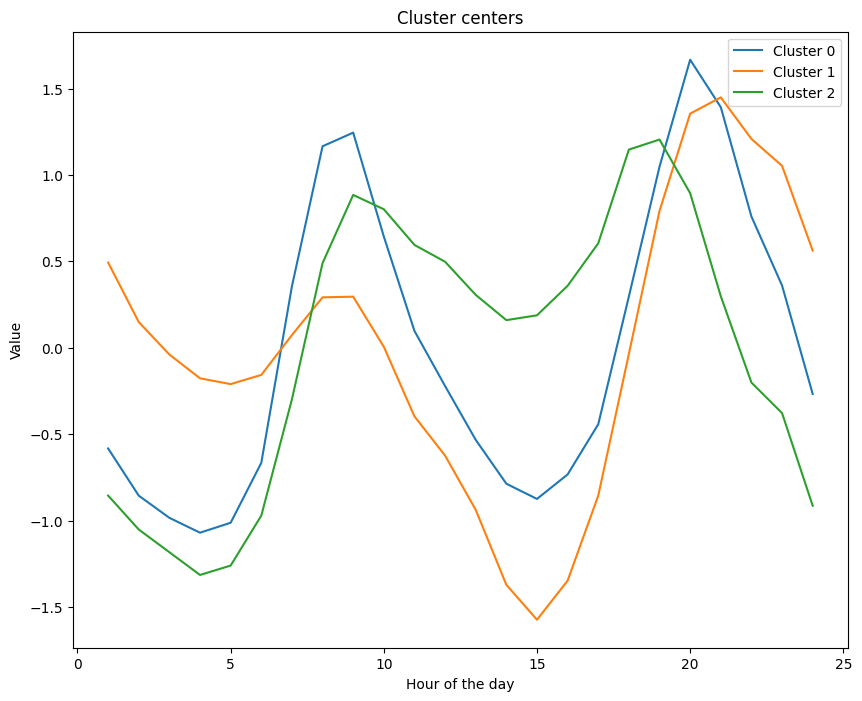

```python
n_clusters=3

kmeans = KMeans(n_clusters=n_clusters, random_state=0, n_init=1000, max_iter=10000)
kmeans.fit(prices_df.iloc[:, :24])
prices_df['cluster'] = kmeans.labels_

hours = range(1, 25)

plt.figure(figsize=(10, 8))

# Plot a line for each day
for i in range(prices_df.shape[0]):
    plt.plot(hours, prices_df.iloc[i, :24], color=plt.cm.viridis(prices_df.iloc[i, -1]/3), alpha=0.5)

#make legend for the colours
for i in range(n_clusters):
    plt.plot([], [], color=plt.cm.viridis(i/3), label='Cluster {}'.format(i))

plt.xlabel('Hour of the day')
plt.ylabel('Value')
plt.title('Line plot for each day colored by cluster')
plt.legend()
plt.show()

#plot kmeans.cluster_centers_
plt.figure(figsize=(10, 8))
plt.plot(hours, kmeans.cluster_centers_.T)
plt.xlabel('Hour of the day')
plt.ylabel('Value')
plt.title('Cluster centers')
plt.legend(['Cluster 0', 'Cluster 1', 'Cluster 2'])
plt.show()
```

The hypothesis from above is supported by the plots below, which show a clear seasonal separation. The histogram shows how many days of each cluster fall within a given month. The second plot also shows a weekly pattern for Cluster 1. Cluster 1, identified as the summer cluster, seems to contain mainly weekend days, which are characterised by low demand, especially in summer.

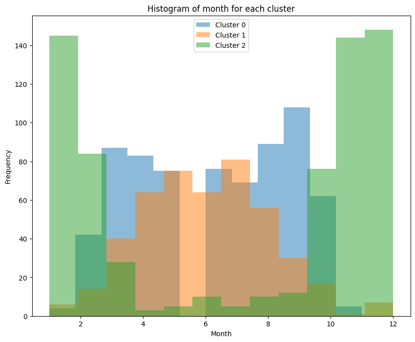

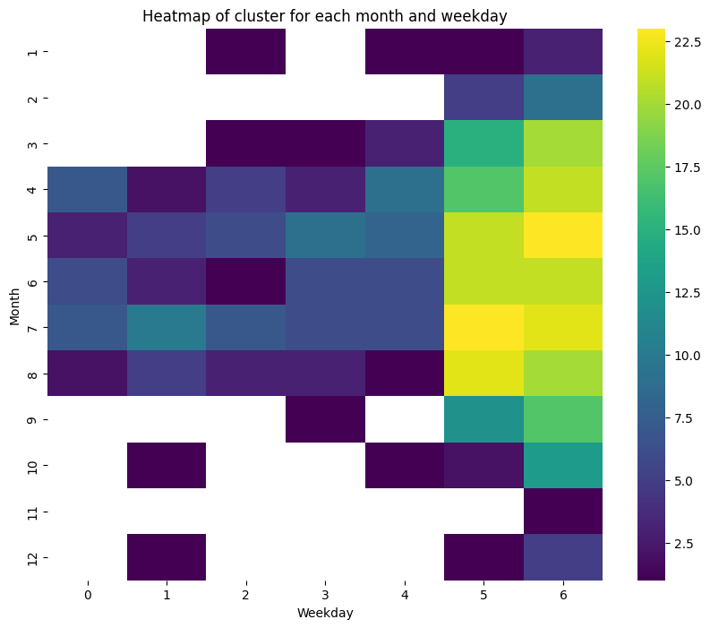

```python
prices_df['month'] = pd.to_datetime(prices_df.index).month
prices_df['weekday'] = pd.to_datetime(prices_df.index).weekday

# make a histogram for each cluster for the month column and weekday column
plt.figure(figsize=(10, 8))
for i in range(n_clusters):
    plt.hist(prices_df[prices_df['cluster'] == i]['month'], alpha=0.5, label='Cluster {}'.format(i), bins=12)
plt.xlabel('Month')
plt.ylabel('Frequency')
plt.title('Histogram of month for each cluster')
plt.legend()
plt.show()

# make a sns heatmap with weekday and month on the x and y axis and the cluster as the color
heatmap_data = prices_df[prices_df['cluster'] == 1].pivot_table(index='month', columns='weekday', values='cluster', aggfunc='count')
import seaborn as sns
plt.figure(figsize=(10, 8))
sns.heatmap(heatmap_data, cmap='viridis')
plt.xlabel('Weekday')
plt.ylabel('Month')
plt.title('Heatmap of cluster for each month and weekday')
plt.show()
```

Based on the cluster centroids, action plans can be derived by multiplying the controids by -1. These action plans will therefore charge during hours with relatively low prices and discharge during price peaks. As the centroids can still be higher than one, but the action plan is to return a percentage of the charge, the positive values are divided by the maximum level and the negative values by the minimum level.

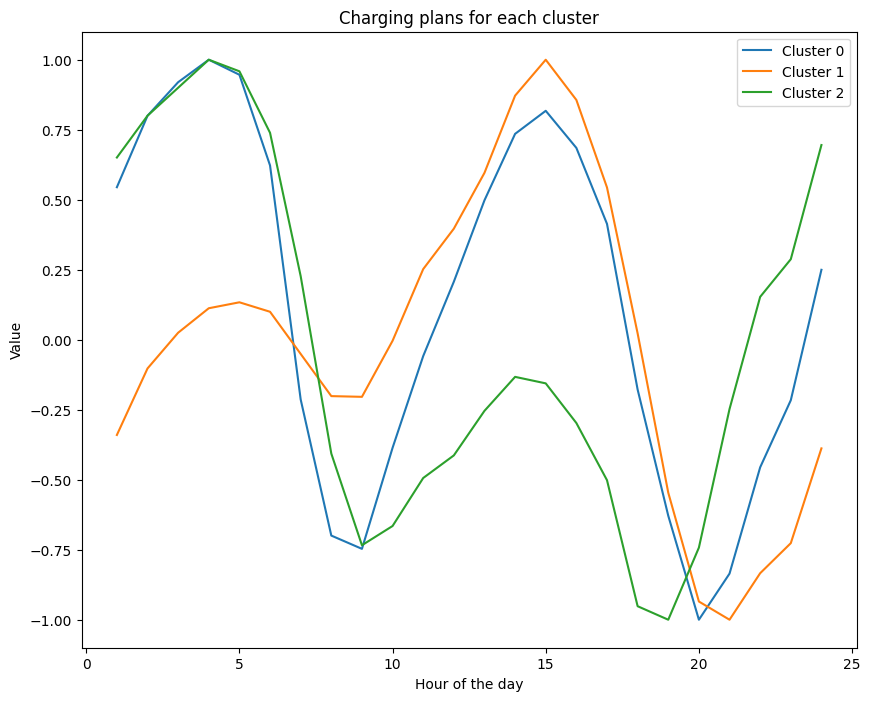

```python
# invert the centroids
centroids = kmeans.cluster_centers_*-1
#divide positive values by max positive value and negative values by max negative value
for i in range(n_clusters):
    max_pos = centroids[i][centroids[i]>0].max()
    max_neg = centroids[i][centroids[i]<0].min()*-1
    centroids[i][centroids[i]>0] = centroids[i][centroids[i]>0]/max_pos
    centroids[i][centroids[i]<0] = centroids[i][centroids[i]<0]/max_neg

plt.figure(figsize=(10, 8))
plt.plot(hours, centroids.T)
plt.xlabel('Hour of the day')
plt.ylabel('Value')
plt.title('Charging plans for each cluster')
plt.legend(['Cluster 0', 'Cluster 1', 'Cluster 2'])
plt.show()
```

In order to increase the number and variety of action plans, three additional plans will be introduced. These plans are based on the previous action plans. Depending on the sign of the hourly value, either a 1 or a -1 is assigned. Another schedule is the maintenance schedule. This plan does not charge or discharge, it just waits. Besides being a realistic day once a year, it can be seen as a lower bound for the RL agent, since it would be chosen if all other plans were losing money. This could happen, for example, with action plan number 7, which is exactly the opposite of action plan 6 and is therefore sub-optimal.

```python
action_4 = centroids[0].copy()
action_4[action_4>0] = 1
action_4[action_4<0] = -1

action_5 = centroids[1].copy()
action_5[action_5>0] = 1
action_5[action_5<0] = -1

action_6 = centroids[2].copy()
action_6[action_6>0] = 1
action_6[action_6<0] = -1
```

```python
#make a dictonary with all the action plans
action_plans_help = {
    0: centroids[0],
    1: centroids[1],
    2: centroids[2],
    3: [0]*24,
    4: action_4,
    5: action_5,
    6: action_6,
    7: action_6*-1
}

keys = list(action_plans_help.keys())

action_plans = {}

for i in range(len(action_plans_help)):
    action_plans[i] = action_plans_help[keys[i]]

#save action plans to csv
action_plans_df = pd.DataFrame.from_dict(action_plans)
action_plans_df.to_csv('action_plans.csv', index=False)
```

# Environment class

The reward is calculated as the sum of the hourly rewards. For each hour, the battery action is taken and added or subtracted depending on the sign. If the total consumption is negative, it means that the company is selling electricity on the market. For each hour, it is checked whether the selected action would exceed the battery capacity, whether below zero or above 100. In these cases, the battery is not charged or discharged, but the winning bid is sold on the balancing market. A realistic assumption for the balancing market would be to sell the bid at 1.2 times the price paid on the day-ahead market. Finally, the hourly remuneration is added up and compared with the cost of electricity that would have been incurred without the battery. The aim is to optimise the daily savings compared to the case without a battery.

```python
class BatteryManagementEnv(Env):
    """
    Custom environment for battery management.

    Parameters:
    - start_day (int): The starting day of the environment (default: 0)

    Attributes:
    - action_space (int): The size of the action space (1)
    - observation_space (int): The size of the observation space (97)
    - max_episode_len (int): The maximum number of steps in an episode (365*5)
    - n_episodes (int): The number of episodes that have been run (-1)
    - charge_rate (int): The amount of charge to increase per step when charging (5)
    - discharge_rate (int): The amount of charge to decrease per step when discharging (5)
    - max_charge (int): The maximum battery charge level (100)
    - min_charge (int): The minimum battery charge level (0)
    - np_random (RandomState): The random number generator
    - t (int): The current time step
    - year (range): The range of years to consider
    - data_year (DataFrame): The data for the selected years
    - charge_level (int): The current battery charge level
    - nA (int): The number of actions in the action plans
    - soc_df (DataFrame): The battery charge level data
    - actions_df (DataFrame): The actions taken data
    - prices_df (DataFrame): The prices data
    - demand_df (DataFrame): The industrial demand data
    - dates_df (DataFrame): The dates data
    - penalty_df (DataFrame): The penalties data
    - lastaction (int): The last action taken
    - lastreward (float): The last reward received
    - total_reward (float): The total reward accumulated

    Methods:
    - seed(seed=None): Set the random seed
    - reset(): Reset the environment to an initial state
    - get_date(day): Get the dates for a given day
    - get_prices(day): Get the prices for a given day
    - get_input_data(day): Get the input data for a given day
    - get_industrial_demand(day): Get the industrial demand for a given day
    - step(action): Take a step in the environment
    """

    def __init__(self, start_day=0):
        # Initialize the environment
        self.start_day = start_day
        self.action_space = 1
        self.observation_space = 97
        self.max_episode_len = 365*5
        self.n_episodes = -1
        self.charge_rate = 5
        self.discharge_rate = 5
        self.max_charge = 100
        self.min_charge = 0
        self.nA = action_plans.shape[1]
        self.soc_df = pd.DataFrame()
        self.actions_df = pd.DataFrame()
        self.prices_df = pd.DataFrame()
        self.demand_df = pd.DataFrame()
        self.dates_df = pd.DataFrame()
        self.penalty_df = pd.DataFrame()
        self.seed()
        self.reset()

    def seed(self, seed=None):
        """
        Set the random seed.

        Parameters:
        - seed (int): The random seed (default: None)

        Returns:
        - seed (list): The random seed used
        """
        self.np_random, seed = seeding.np_random(seed)
        return [seed]

    def reset(self):
        """
        Reset the environment to an initial state.

        Returns:
        - state (ndarray): The initial state of the environment
        """
        self.t = self.start_day
        self.year = range(2019, 2024)
        self.data_year = data[data['year'].isin(self.year)]
        self.data_year = self.data_year.reset_index(drop=True)
        self.charge_level = 10
        self.n_episodes += 1
        self.soc_list = []
        self.actions = []
        self.prices = []
        self.demand = []
        self.dates = []
        self.penalties = []
        input = self.get_input_data(self.t)
        self.state = np.array([self.charge_level]+input)
        self.lastaction = None
        self.lastreward = None
        self.total_reward = 0
        return self.state

    def get_date(self, day):
        """
        Get the dates for a given day.

        Parameters:
        - day (int): The day index

        Returns:
        - dates (list): The dates for the given day
        """
        return list(self.data_year['date'][day*24:day*24+24])

    def get_prices(self, day):
        """
        Get the prices for a given day.

        Parameters:
        - day (int): The day index

        Returns:
        - prices (list): The prices for the given day
        """
        return list(self.data_year['price_GER'][day*24:day*24+24])

    def get_input_data(self, day):
        """
        Get the input data for a given day.

        Parameters:
        - day (int): The day index

        Returns:
        - input_array (list): The input data for the given day
        """
        input_array = list(self.data_year['solar_forecastGER'][day*24:day*24+24])
        input_array += list(self.data_year['windonshore_forecastGER'][day*24:day*24+24])
        input_array += list(self.data_year['windoffshore_forecastGER'][day*24:day*24+24])
        input_array += list(self.data_year['load_GER'][day*24:day*24+24])
        return input_array

    def get_industrial_demand(self, day):
        """
        Get the industrial demand for a given day.

        Parameters:
        - day (int): The day index

        Returns:
        - industrial_demand (list): The industrial demand for the given day
        """
        return list(self.data_year['industrial_demand'][day*24:day*24+24])

    def step(self, action):
        """
        Take a step in the environment.

        Parameters:
        - action (int): The action to take

        Returns:
        - state (ndarray): The next state
        - reward (float): The reward for the current step
        - done (bool): Whether the episode is done or not
        - info (dict): Additional information
        """
        self.lastaction = action
        prices = self.get_prices(self.t)
        input = self.get_input_data(self.t)
        industrial_demand = self.get_industrial_demand(self.t)
        dates = self.get_date(self.t)
        self.state[1:] = input
        for i in range(len(prices)):
            self.prices.append(prices[i])
            self.demand.append(industrial_demand[i])
            self.dates.append(dates[i])
        done= False
        action_dict = {}
        for i in range(action_plans.shape[1]):
            action_dict[i] = list(action_plans.iloc[:, i])
        selected_action = action_dict[action]
        daily_cost = 0
        for hour in range(24):
            cost = 0
            if selected_action[hour] > 0:
                new_charge_level = self.state[0] + self.charge_rate*selected_action[hour]
                if new_charge_level <= self.max_charge:
                    self.state[0] = new_charge_level
                    self.actions.append(selected_action[hour])
                    self.penalties.append(0)
                    cost += (self.charge_rate*selected_action[hour] + industrial_demand[hour])*prices[hour]
                else:
                    cost += (1.2*self.charge_rate*selected_action[hour] + industrial_demand[hour])*prices[hour]
                    self.penalties.append(1)
                    self.actions.append(0)
            elif selected_action[hour] < 0:
                new_charge_level = self.state[0] + self.discharge_rate*selected_action[hour]
                if new_charge_level >= self.min_charge:
                    self.state[0] = new_charge_level
                    self.actions.append(selected_action[hour])
                    self.penalties.append(0)
                    cost += (self.discharge_rate*selected_action[hour] + industrial_demand[hour])*prices[hour]
                else:
                    self.actions.append(0)
                    self.penalties.append(1)
                    cost += (-1.2* self.discharge_rate*selected_action[hour] + industrial_demand[hour])*prices[hour]  # Penalty for trying to overdischarge

            elif selected_action[hour] == 0:  # do nothing
                cost += industrial_demand[hour]*prices[hour]
                self.actions.append(0)
                self.penalties.append(0)

            daily_cost += cost
            self.soc_list.append(self.state[0])

        daily_reward = (sum([a*b for a,b in zip(prices, industrial_demand)]) - daily_cost)
        self.total_reward += daily_reward
        self.lastreward = daily_reward
        self.t += 1

        if self.t>= self.max_episode_len:
            self.soc_df[self.n_episodes] = self.soc_list
            self.actions_df[self.n_episodes] = self.actions
            self.prices_df[self.n_episodes] = self.prices
            self.demand_df[self.n_episodes] = self.demand
            self.dates_df[self.n_episodes] = self.dates
            self.penalty_df[self.n_episodes] = self.penalties

            self.soc_df.to_csv('results/soc_df.csv')
            self.actions_df.to_csv('results/actions_df.csv')
            self.prices_df.to_csv('results/prices_df.csv')
            self.demand_df.to_csv('results/demand_df.csv')
            self.dates_df.to_csv('results/dates_df.csv')
            self.penalty_df.to_csv('results/penalty_df.csv')

            return (self.state, daily_reward, True, {})  # (nextstate, reward, done, info)

        done = False
        info = {}  # Additional information

        return self.state, daily_reward, done, info
```

## Neural network

The implementation of the neural network is quite simple. First, the input features are flattened, then three hidden layers with a relu function are used. Finally, a layer with a linear function provides the q-value estimates. Based on these values, the RL agent decides which action to take. A deep Q-learning setting is needed because the input features are continuous and the sheer number of features is too large for a regular Q-table.

```python
def build_enhanced_model(states, actions):
    """
    Build an enhanced model for reinforcement learning.

    Args:
        states (int): The number of states in the environment.
        actions (int): The number of possible actions in the environment.

    Returns:
        keras.Model: The built Keras model.

    """
    # Define the input layer
    input_layer = Input(shape=(1,states))  # Adjusted for a flat input vector

    # Flatten the input if it's multidimensional
    if len(input_layer.shape) > 2:
        x = Flatten()(input_layer)
    else:
        x = input_layer

    x = Dense(32, activation='relu')(x)
    x = Dropout(0.2)(x)

    x= Dense(64, activation='relu')(x)
    x = Dropout(0.2)(x)

    x = Dense(32, activation='relu')(x)
    x = Dropout(0.2)(x)

    # Output layer
    output = Dense(actions, activation='linear')(x)

    # Create the Keras Model
    model = Model(inputs=input_layer, outputs=output)
    model.compile(optimizer=Adam(learning_rate=0.001), loss='mse')

    return model
```

```python
data = pd.read_csv('data.csv')
prices = data[['price_GER']]
industrial_demand = data[['industrial_demand']]
action_plans = pd.read_csv('../final_project/action_plans.csv', header=0)

env = BatteryManagementEnv(0)
model = build_enhanced_model(env.observation_space, env.nA)
```

```python
# Then, define DQN agent in Keras-RL
memory = SequentialMemory(limit=20000, window_length=1)
policy = LinearAnnealedPolicy(EpsGreedyQPolicy(eps=0.005),
                              attr='eps', value_max=1., value_min=.1, value_test=.05, nb_steps=10000)
dqn = DQNAgent(model=model, nb_actions=env.nA, memory=memory, policy=policy,
                nb_steps_warmup=500, target_model_update=1e-2, enable_double_dqn=True, enable_dueling_network=True)
dqn.compile(optimizer=Adam(learning_rate=1e-3), metrics=['mae'])
```

```python
def train_model(seed, env, nb_steps, nb_max_episode_steps):
    """
    Trains a model using the DQN algorithm.

    Args:
        seed (int): The seed value for reproducibility.
        env (object): The environment object.
        nb_steps (int): The total number of training steps.
        nb_max_episode_steps (int): The maximum number of steps per episode.

    Returns:
        str: The filename of the log file generated during training.
    """
    # Set the seed for reproducibility
    np.random.seed(seed)
    env.seed(seed)
    tf.random.set_seed(seed)

    # Logger
    log_filename = f'results/dqn_BatteryManagementEnv_log_seed_{seed}.json'
    logger = FileLogger(log_filename, interval=nb_max_episode_steps)

    # Training
    dqn.fit(env, nb_steps=nb_steps, visualize=False, verbose=1, nb_max_episode_steps=nb_max_episode_steps, log_interval=nb_max_episode_steps,callbacks=[logger])

    return log_filename

def plot_training_progress(log_files):
    all_rewards = []

    # Collect rewards from all log files
    for log_file in log_files:
        with open(log_file, 'r') as file:
            data = json.load(file)
            all_rewards.append(data['episode_reward'])  # Ensure the key matches your JSON structure

    # Convert to a NumPy array for easier manipulation
    all_rewards = np.array(all_rewards)

    # Calculate mean and standard deviation
    rewards_mean = np.mean(all_rewards, axis=0)
    rewards_std = np.std(all_rewards, axis=0)

    episodes = np.arange(len(rewards_mean)) + 1  # Episode indices

    # Plotting
    plt.figure(figsize=(12, 6))
    plt.plot(episodes, rewards_mean, label='Mean Reward', color='blue')  # Line plot for the mean rewards
    plt.fill_between(episodes, rewards_mean - rewards_std, rewards_mean + rewards_std, color='blue', alpha=0.3, label='Standard Deviation')  # Shaded area for the standard deviation
    plt.title('Training Rewards Over Episodes Across Different Seeds')
    plt.xlabel('Episodes')
    plt.ylabel('Rewards')
    plt.legend()
    plt.grid(True)
    plt.show()
```

The model is trained according to a predefined function. In this function, the model is fitted to the same data with different seeds and the results are logged in json files. The training is done on data from 2019-2022, i.e. 1460 days. Previous runs have shown that the models converge after about 10 episodes. The number of episodes is set to 15. A plot is then generated from the json files showing the average episode reward per episode and an interval with the corresponding standard deviation. The model converges to a level of around €1,800,000 in electricity cost savings in each episode. As each episode consists of four years, the annual savings are around €450,000.

```
Training for 21900 steps ...
Interval 1 (0 steps performed)
1 episodes - episode_reward: 446157.440 [446157.440, 446157.440] - loss: 10803005.301 - mae: 8083.919 - mean_q: 11655.669 - mean_eps: 0.912

Interval 2 (1460 steps performed)
1 episodes - episode_reward: 215490.496 [215490.496, 215490.496] - loss: 3437207.914 - mae: 2204.578 - mean_q: 3440.698 - mean_eps: 0.803

Interval 3 (2920 steps performed)
1 episodes - episode_reward: 733173.335 [733173.335, 733173.335] - loss: 4407231.186 - mae: 2011.552 - mean_q: 2975.514 - mean_eps: 0.672

Interval 4 (4380 steps performed)
1 episodes - episode_reward: 1168967.039 [1168967.039, 1168967.039] - loss: 4084403.816 - mae: 2207.572 - mean_q: 3267.810 - mean_eps: 0.540

Interval 5 (5840 steps performed)
1 episodes - episode_reward: 1445827.073 [1445827.073, 1445827.073] - loss: 3993095.273 - mae: 2372.618 - mean_q: 3570.930 - mean_eps: 0.409

Interval 6 (7300 steps performed)
1 episodes - episode_reward: 1742615.044 [1742615.044, 1742615.044] - loss: 3801696.665 - mae: 2401.999 - mean_q: 3675.230 - mean_eps: 0.277

Interval 7 (8760 steps performed)
1 episodes - episode_reward: 1958177.316 [1958177.316, 1958177.316] - loss: 3416754.035 - mae: 2304.861 - mean_q: 3548.782 - mean_eps: 0.147

Interval 8 (10220 steps performed)
1 episodes - episode_reward: 2024251.472 [2024251.472, 2024251.472] - loss: 3373978.177 - mae: 2303.862 - mean_q: 3614.777 - mean_eps: 0.100

Interval 9 (11680 steps performed)
1 episodes - episode_reward: 1917224.690 [1917224.690, 1917224.690] - loss: 3264862.360 - mae: 2247.415 - mean_q: 3459.536 - mean_eps: 0.100

Interval 10 (13140 steps performed)
1 episodes - episode_reward: 1969763.367 [1969763.367, 1969763.367] - loss: 3197605.724 - mae: 2180.228 - mean_q: 3450.299 - mean_eps: 0.100

Interval 11 (14600 steps performed)
1 episodes - episode_reward: 1957882.652 [1957882.652, 1957882.652] - loss: 3094191.957 - mae: 2203.616 - mean_q: 3407.893 - mean_eps: 0.100

Interval 12 (16060 steps performed)
1 episodes - episode_reward: 2033587.742 [2033587.742, 2033587.742] - loss: 2977872.699 - mae: 2153.590 - mean_q: 3377.527 - mean_eps: 0.100

Interval 13 (17520 steps performed)
1 episodes - episode_reward: 2004702.188 [2004702.188, 2004702.188] - loss: 2963109.110 - mae: 2165.989 - mean_q: 3384.295 - mean_eps: 0.100

```

[output cut: 215 more lines]

```

Interval 11 (14600 steps performed)
1 episodes - episode_reward: 1114178.992 [1114178.992, 1114178.992] - loss: 2864730.531 - mae: 2136.573 - mean_q: 3294.265 - mean_eps: 0.100

Interval 12 (16060 steps performed)
1 episodes - episode_reward: 1889954.625 [1889954.625, 1889954.625] - loss: 2939683.056 - mae: 2081.009 - mean_q: 3256.311 - mean_eps: 0.100

Interval 13 (17520 steps performed)
1 episodes - episode_reward: 1876406.594 [1876406.594, 1876406.594] - loss: 2916262.497 - mae: 2150.892 - mean_q: 3377.258 - mean_eps: 0.100

Interval 14 (18980 steps performed)
1 episodes - episode_reward: 1872841.314 [1872841.314, 1872841.314] - loss: 2925801.787 - mae: 2130.177 - mean_q: 3302.327 - mean_eps: 0.100

Interval 15 (20440 steps performed)
done, took 176.862 seconds
```

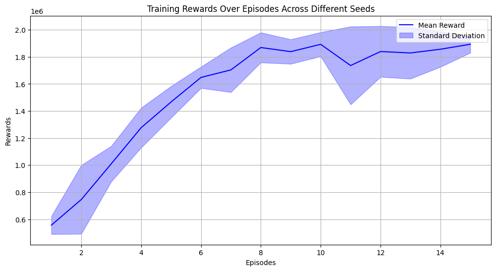

```python
nb_max_episode_steps = 365*4
nb_steps = nb_max_episode_steps*15
seeds = [142, 1123, 1456, 1789, 11011, 12345]
log_files = []

for seed in seeds:
    log_files.append(train_model(seed, env, nb_steps, nb_max_episode_steps))

plot_training_progress(log_files)
```

```python
#load results files and plot the results
soc_df = pd.read_csv('results/soc_df.csv', index_col=0)
actions_df = pd.read_csv('results/actions_df.csv', index_col=0)
prices_df = pd.read_csv('results/prices_df.csv', index_col=0)
demand_df = pd.read_csv('results/demand_df.csv', index_col=0)
dates_df = pd.read_csv('results/dates_df.csv', index_col=0)
penalty_df = pd.read_csv('results/penalty_df.csv', index_col=0)

result_dict = {}
best_day = {}

for i in range(soc_df.shape[1]):
    key = str(i+1)
    result_df = pd.concat([dates_df[key], demand_df[key], actions_df[key], prices_df[key], soc_df[key], penalty_df[key]], axis=1)
    result_df.columns = ['date', 'demand', 'action', 'price', 'soc', 'penalty']
    result_df['charge'] = result_df['action']*5
    result_df['demand_costs'] = result_df['demand']*result_df['price']
    result_df['charge_costs'] = result_df['charge']*result_df['price']
    result_df['total_costs'] = result_df['demand_costs'] + result_df['charge_costs']
    result_df['savings'] = result_df['demand_costs'] - result_df['total_costs']
    result_df['fee'] = 1.2*result_df['penalty']*result_df['price']

    result_df['date'] = pd.to_datetime(result_df['date'])
    result_df = result_df.set_index('date')
    #groupby day and sum the savings
    daily_result_df = result_df.groupby(result_df.index.date).sum()
    #change index to column
    daily_result_df['date'] = daily_result_df.index
    daily_result_df.reset_index(drop=True, inplace=True)
    #return index with highest savings and no penalties
    max_saving = daily_result_df[(daily_result_df['penalty'] == 0)]['savings'].idxmax()
    best_day[i] = daily_result_df.iloc[max_saving]

    result_dict[i] = result_df
```

```python
#select day which is in all best days
selected_day = best_day[0]
plot_df = result_dict[0].loc[result_dict[0].index.date == selected_day['date']]

plot_df['date'] = plot_df.index
plot_df.reset_index(drop=True, inplace=True)
plot_df['date'] = pd.to_datetime(plot_df['date'], format='%Y-%m-%d %H:%M:%S')
plot_df['hour'] = plot_df['date'].dt.hour
```

An example of a day is shown in the diagram below. In this case, the battery discharges for two hours, followed by a four-hour charging period and a four-hour discharging period. The battery then charges for eight hours and discharges for six hours until the end of the day. The capacity changes according to the selected action and the battery is discharged entirely twice during the day. The very low electricity prices in the early afternoon are exploited with a long charging interval. The battery is discharged during the hours of high prices in the evening and early morning. However, the battery could be improved as the second discharge occurs at a time when electricity prices are negative and higher consumption would actually result in lower electricity prices.

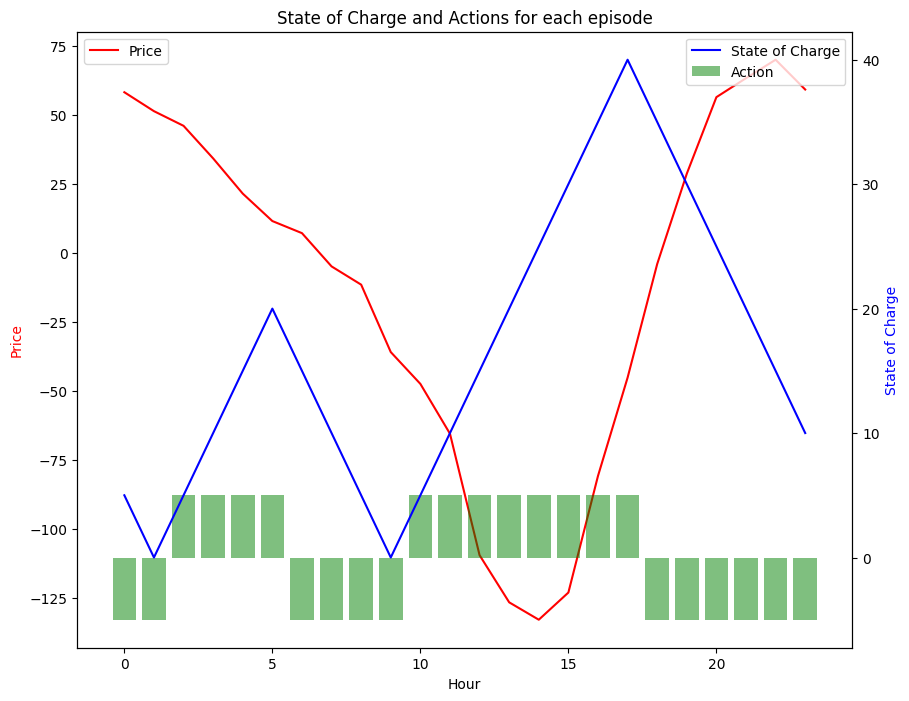

```python
# Set figure size
fig, ax1 = plt.subplots(figsize=(10, 8))

# Plot state of charge on the primary axis
ax1.plot(plot_df['hour'], plot_df['price'], label='Price', color='red')
ax1.set_xlabel('Hour')
ax1.set_ylabel('Price', color='red')

# Create a twin axis sharing the same x-axis
ax2 = ax1.twinx()

# Plot actions as bars on the secondary axis
ax2.bar(plot_df['hour'], plot_df['charge'], label='Action', color='green', alpha=0.5)
ax2.set_ylabel('Action', color='green')

# Plot state of charge on the primary axis
ax2.plot(plot_df['hour'], plot_df['soc'], label='State of Charge', color='blue')
ax2.set_xlabel('Hour')
ax2.set_ylabel('State of Charge', color='blue')

# Set title
plt.title('State of Charge and Actions for each episode')

# Add legend
ax1.legend(loc='upper left')
ax2.legend(loc='upper right')

# Display plot
plt.show()
```

```python
env_test = BatteryManagementEnv(365*4)  # Adjusted for testing phase

dqn.test(env_test, nb_episodes=1, visualize=False, nb_max_episode_steps=365, verbose=1)
```

```
Testing for 1 episodes ...
Episode 1: reward: 582023.029, steps: 365
```

```
<keras.src.callbacks.History at 0x183240f90d0>
```

# Conclusion

Overall, the model successfully reduces electricity costs. Clustering identifies distinct and meaningful clusters of price patterns, which are translated into charging plans. The neural network is able to learn and estimate q-values for the agent, based on the provided forecast values for load, wind and solar generation. The agent itself learns quite quickly and converges after about 10 episodes. The model even performs well on the test set and achieves electricity cost savings. This report can be the beginning of a deeper research in the area of RL in battery management systems. The complexity can be increased, for example by increasing the number of charging plans. Instead of using an artificially created demand profile, the model could be trained and tested on real load profiles. Another possible research direction would be to predict electricity prices and customer demand as input parameters to an optimisation problem. This approach could have lower computational requirements, but this hypothesis needs to be proven.